# Puppy Raiser Questionnaire vs Outcome (W, AD, GD)

Marinara Marcato

## Introduction

This document tests the hypothesis that there is a difference in behaviours reported in the standardised questionnaire Canine Behavioural Assessement & Research Questionnaire (C-BARQ) considering dog’s training status (W, AD, GD).

## Data Exploration

### Columns: Variables

Below are the questionnaire items(variables) that were scored by the Puppy Raise in a scale from 0 = ‘Never’, 1 = ‘Seldom’, 2 = ‘Sometimes’, 3 = ‘Usually’, 4 = ‘Always’.

```
##
## comments     info  ordinal
##        4       14      115
```

### Rows: Dogs

The number of dogs in the Puppy Raiser Questionnaire dataset. Selection criteria: dogs with a defined training outcome.

```
## Number of unique dogs: 63
```

```
## Training Outcome Status:
```

```
##
## AD GD  W
## 26 26 11
```

```
## Number of unique dogs with defined Training Outcome: 63
```

Analysing categorical demographic data: Sex, Breed

```
##
##  F  M
## 30 33
```

```
##
## GRxPoodle        GS        LR       LRx     LRxGR
##         1         1        25         9        27
```

Analysing age at assessment:

```
## Age at Assessment: Mean 16.12559 Standard Deviation 3.404516
```

## Data

1. Stranger-directed aggression: Dog shows threatening or aggressive responses to strangers approaching or invading the dog’s or the owner’s personal space, territory, or home range.
2. Owner-directed aggression: Dog shows threatening or aggressive responses to the owner or other members of the household when challenged, manhandled, stared at, stepped over, or when approached while in possession of food or objects.
3. Dog-directed aggression: Dog shows threatening or aggressive responses when approached directly by unfamiliar dogs.
4. Dog rivalry: Dog shows aggressive or threatening responses to other familiar dogs in the same household.
5. Stranger-directed fear: Dog shows fearful or wary responses when approached directly by strangers.
6. Nonsocial fear: Dog shows fearful or wary responses to sudden or loud noises (e.g. thunder), traffic, and unfamiliar objects and situations.
7. Dog-directed fear: Dog shows fearful or wary responses when approached directly by unfamiliar dogs.
8. Touch sensitivity: Dog shows fearful or wary responses to potentially painful or uncomfortable procedures, including bathing, grooming, nail-clipping, and veterinary examinations.
9. Separation-related behavior: Dog vocalizes and/or is destructive when separated from the owner, often accompanied or preceded by behavioral and autonomic signs of anxiety including restlessness, loss of appetite, trembling, and excessive salivation.
10. Attachment and attention-seeking: Dog maintains close proximity to the owner or other members of the household, solicits affection or attention, and displays agitation when the owner gives attention to third parties.
11. Trainability: Dog shows a willingness to attend to the owner and obey simple commands. Dog is not easily distracted, tends to be a fast learner, responds positively to correction, and will fetch or retrieve objects.
12. Chasing: Dog chases cats, birds, and/or other small animals, given the opportunity.
13. Excitability: Dog displays strong reaction to potentially exciting or arousing events, such as going for walks or car trips, doorbells, arrival of visitors, and the owner arriving home; has difficulty calming down after such events.
14. Energy level: Dog is energetic, ‘always on the go’, and/or playful.

## Data Analysis

```
##  [1] "X1.When.off.the.leash.returns.immediately.when.called"
##  [2] "X26.Toward.unfamiliar.dogs.visiting.your.home"
##  [3] "X27.Toward.cats.squirrels.or.other.small.animals.entering.your.yard"
##  [4] "X29.When.barked.growled.or.lunged.at.by.another.unfamiliar.dog"
##  [5] "X40.When.an.unfamiliar.person.tries.to.touch.or.pet.the.dog"
##  [6] "X52.When.unfamiliar.dogs.visit.your.home"
##  [7] "X54.Shaking.shivering.or.trembling"
##  [8] "X57.Whining"
##  [9] "X62.When.you.or.other.members.of.the.household.come.home.after.a.brief.absence"
## [10] "X63.When.playing.with.you.or.other.members.of.your.household"
## [11] "X77.Escapes.or.would.escape.from.home.or.yard.given.the.chance"
## [12] "X90.Hyperactive.restless.has.trouble.settling.down"
## [13] "X99.Licks.people.or.objects.excessively"
## [14] "F_03.Dog.directed.aggression"
## [15] "F_10.Separation.related.problems"
## [16] "F_12.Excitability"
```

## Outcome

Below are the variables that showed statistically significant differences in behaviours considering different Training Outcomes (W, AD, GD).

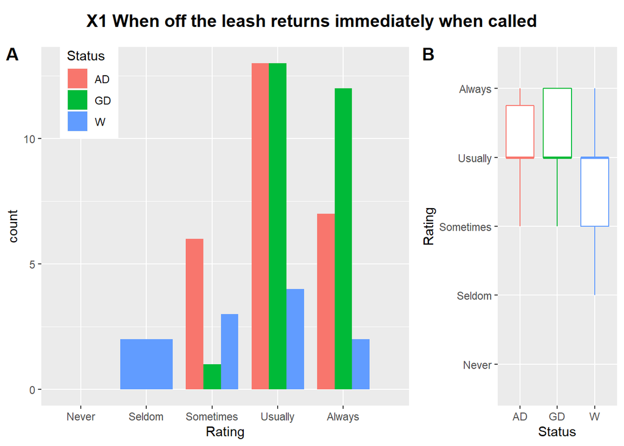

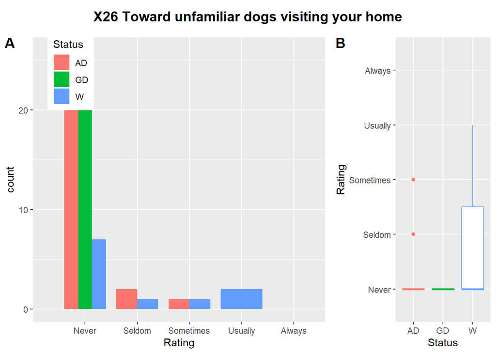

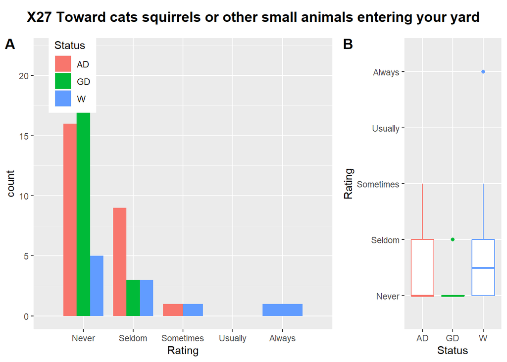

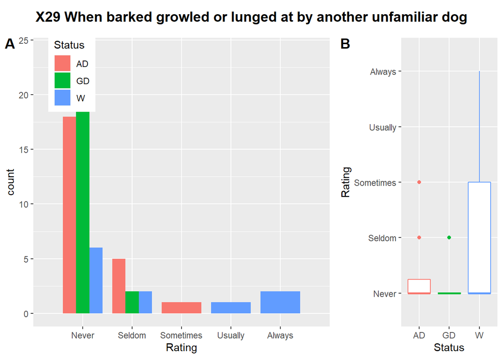

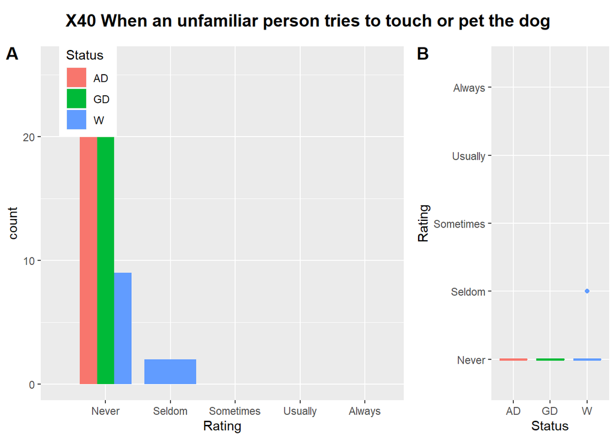

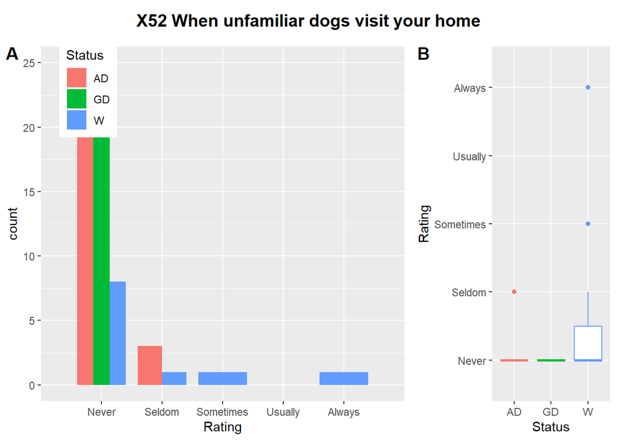

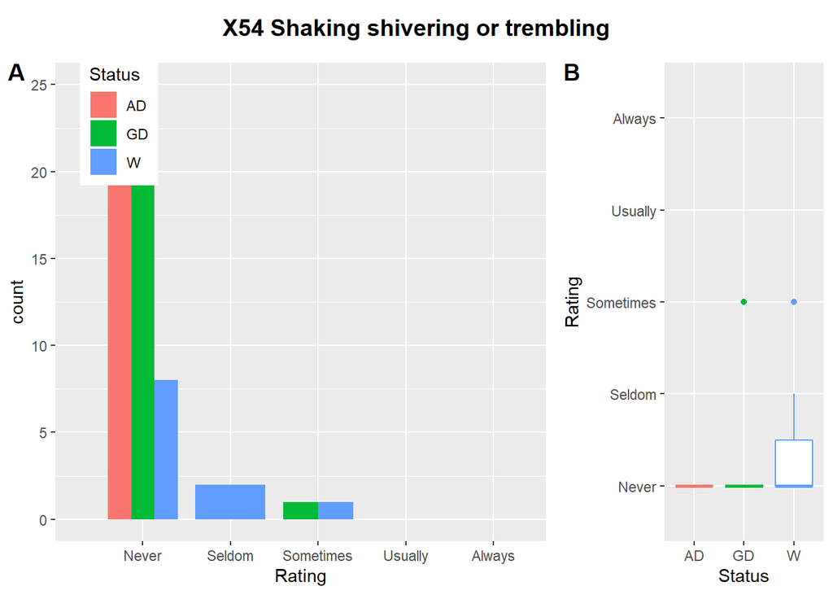

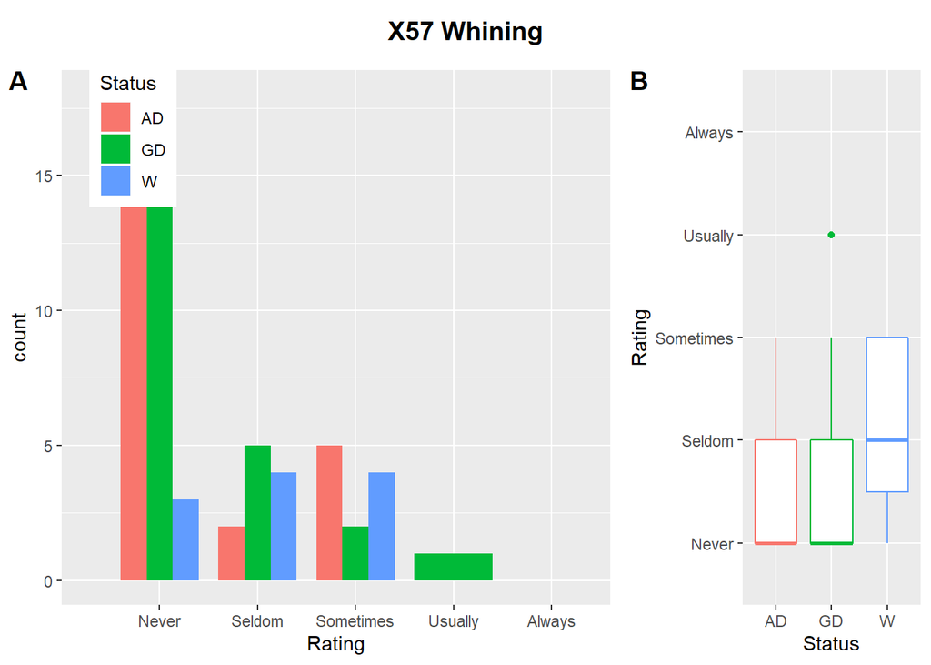

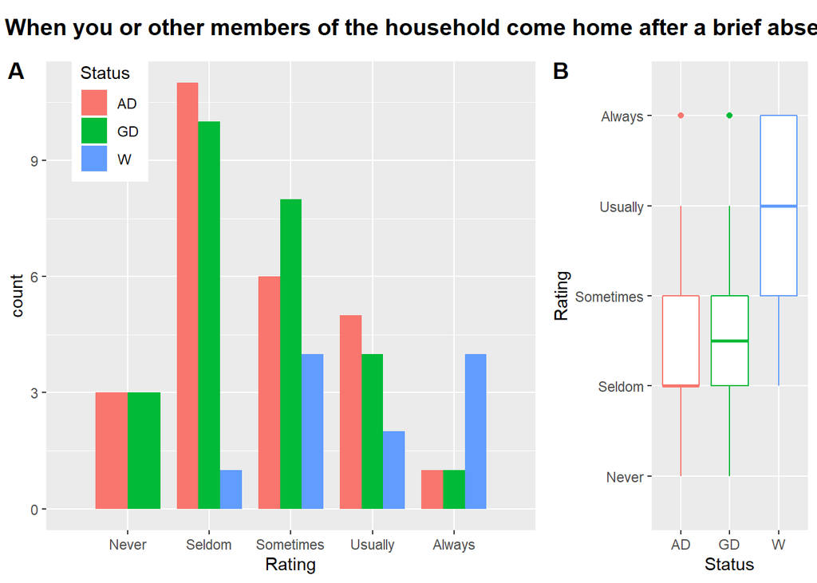

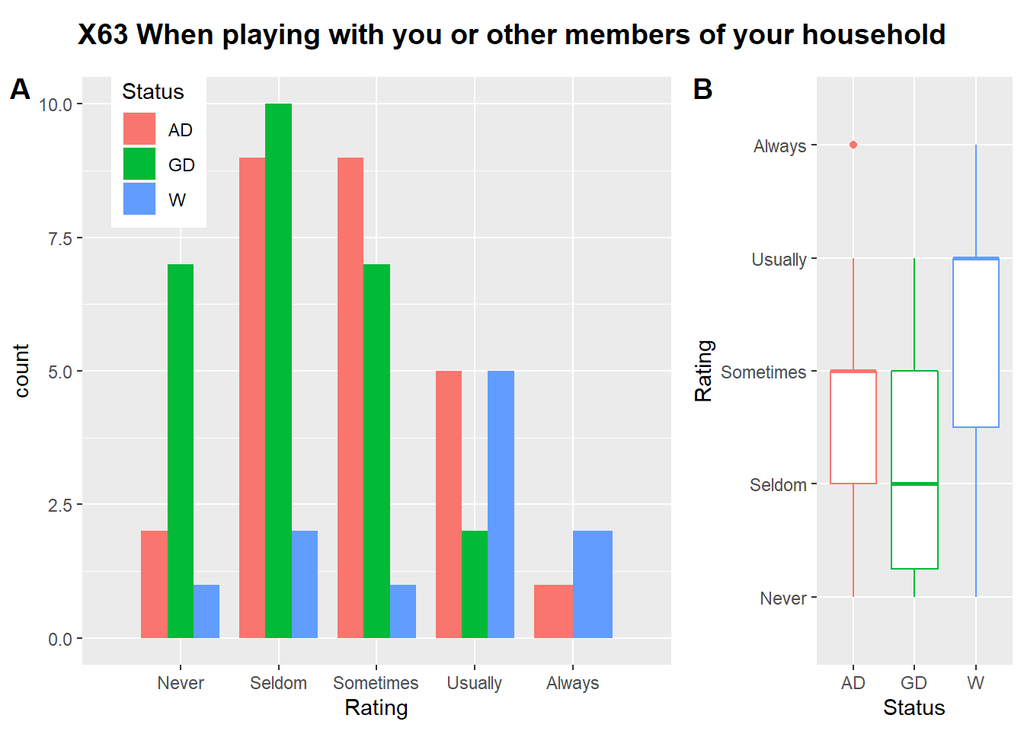

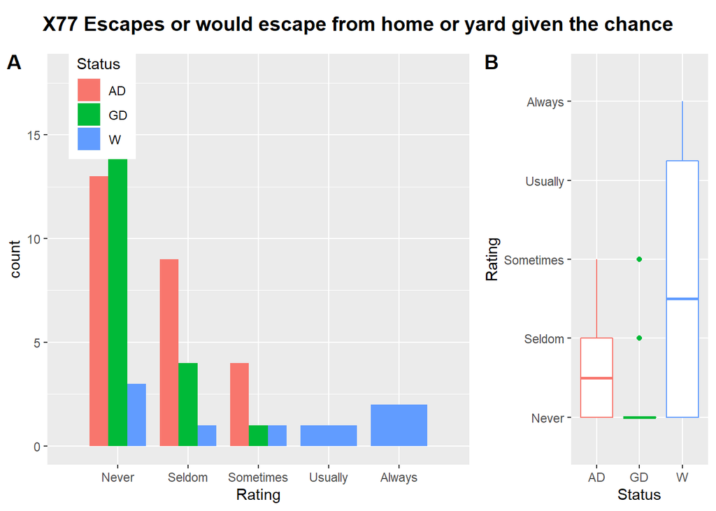

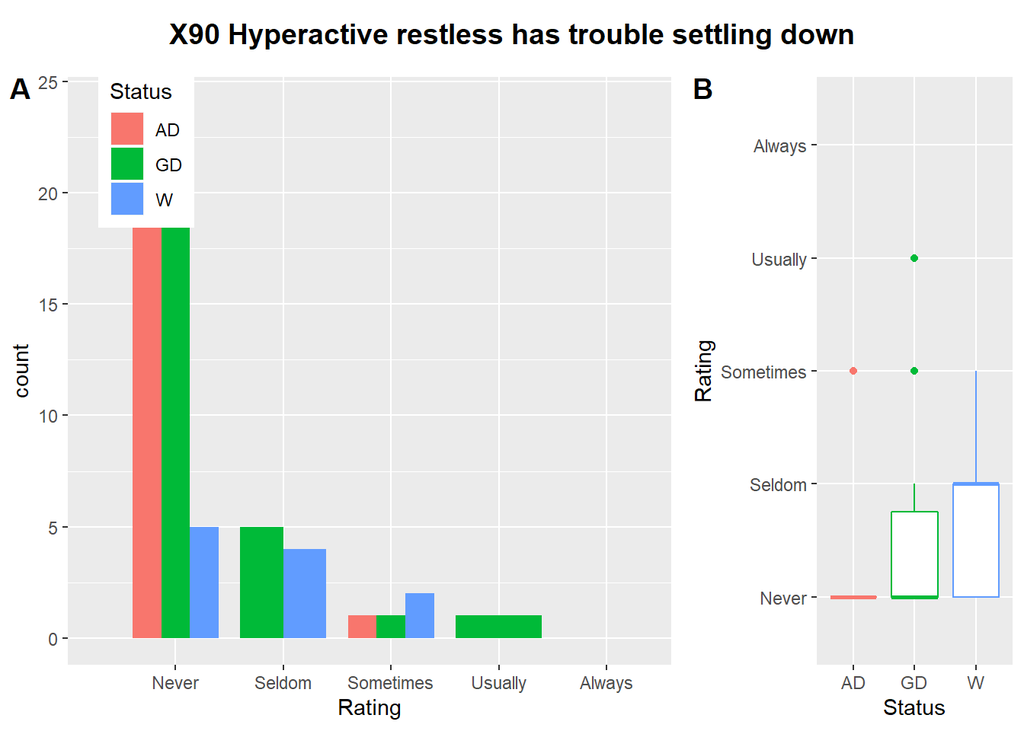

[4 more figures not shown]